# Assignment 2 - Regression

```python
import sklearn

assert sklearn.__version__ >= "1.0.1"
```

```python
import matplotlib as mpl
import matplotlib.pyplot as plt

from sklearn.linear_model import Ridge, RidgeCV, Lasso
from sklearn.preprocessing import StandardScaler
from sklearn.model_selection import train_test_split
from sklearn.linear_model import LinearRegression
from sklearn.metrics import mean_absolute_error
from sklearn.metrics import mean_squared_error
from sklearn.metrics import r2_score
from sklearn.ensemble import RandomForestRegressor
from sklearn.model_selection import cross_val_score

import pandas as pd
import numpy as np
import matplotlib.pyplot as plt


plt.rc('font', size=14)
plt.rc('axes', labelsize=14, titlesize=14)
plt.rc('legend', fontsize=14)
plt.rc('xtick', labelsize=10)
plt.rc('ytick', labelsize=10)
```

```python
from pathlib import Path

IMAGES_PATH = Path() / "03_regression_images" / "regression"
IMAGES_PATH.mkdir(parents=True, exist_ok=True)

def save_fig(fig_id, tight_layout=True, fig_extension="png", resolution=300):
    path = IMAGES_PATH / f"{fig_id}.{fig_extension}"
    if tight_layout:
        plt.tight_layout()
    plt.savefig(path, format=fig_extension, dpi=resolution)
```

Vor dem Trainieren des Regressionmodells, werden erst einige Merkmale und ihr Zusammenhang grafisch dragestellt, um ein Gefühl für den Datensatz zu bekommen.

```python
bike_data = pd.read_csv("02_Bike_rental.csv",sep=',')

bike_data['dteday'] = pd.to_datetime(bike_data['dteday'])

bike_data.head()
```

|  | instant | dteday | season | yr | mnth | holiday | weekday | workingday | weathersit | temp | atemp | hum | windspeed | casual | registered | cnt |
| --- | --- | --- | --- | --- | --- | --- | --- | --- | --- | --- | --- | --- | --- | --- | --- | --- |
| 0 | 1 | 2011-01-01 | 1 | 0 | 1 | 0 | 6 | 0 | 2 | 0.344167 | 0.363625 | 0.805833 | 0.160446 | 331 | 654 | 985 |
| 1 | 2 | 2011-01-02 | 1 | 0 | 1 | 0 | 0 | 0 | 2 | 0.363478 | 0.353739 | 0.696087 | 0.248539 | 131 | 670 | 801 |
| 2 | 3 | 2011-01-03 | 1 | 0 | 1 | 0 | 1 | 1 | 1 | 0.196364 | 0.189405 | 0.437273 | 0.248309 | 120 | 1229 | 1349 |
| 3 | 4 | 2011-01-04 | 1 | 0 | 1 | 0 | 2 | 1 | 1 | 0.200000 | 0.212122 | 0.590435 | 0.160296 | 108 | 1454 | 1562 |
| 4 | 5 | 2011-01-05 | 1 | 0 | 1 | 0 | 3 | 1 | 1 | 0.226957 | 0.229270 | 0.436957 | 0.186900 | 82 | 1518 | 1600 |

```python
bike_data.describe()
```

|  | instant | season | yr | mnth | holiday | weekday | workingday | weathersit | temp | atemp | hum | windspeed | casual | registered | cnt |
| --- | --- | --- | --- | --- | --- | --- | --- | --- | --- | --- | --- | --- | --- | --- | --- |
| count | 731.000000 | 731.000000 | 731.000000 | 731.000000 | 731.000000 | 731.000000 | 731.000000 | 731.000000 | 731.000000 | 731.000000 | 731.000000 | 731.000000 | 731.000000 | 731.000000 | 731.000000 |
| mean | 366.000000 | 2.496580 | 0.500684 | 6.519836 | 0.028728 | 2.997264 | 0.683995 | 1.395349 | 0.495385 | 0.474354 | 0.627894 | 0.190486 | 848.176471 | 3656.172367 | 4504.348837 |
| std | 211.165812 | 1.110807 | 0.500342 | 3.451913 | 0.167155 | 2.004787 | 0.465233 | 0.544894 | 0.183051 | 0.162961 | 0.142429 | 0.077498 | 686.622488 | 1560.256377 | 1937.211452 |
| min | 1.000000 | 1.000000 | 0.000000 | 1.000000 | 0.000000 | 0.000000 | 0.000000 | 1.000000 | 0.059130 | 0.079070 | 0.000000 | 0.022392 | 2.000000 | 20.000000 | 22.000000 |
| 25% | 183.500000 | 2.000000 | 0.000000 | 4.000000 | 0.000000 | 1.000000 | 0.000000 | 1.000000 | 0.337083 | 0.337842 | 0.520000 | 0.134950 | 315.500000 | 2497.000000 | 3152.000000 |
| 50% | 366.000000 | 3.000000 | 1.000000 | 7.000000 | 0.000000 | 3.000000 | 1.000000 | 1.000000 | 0.498333 | 0.486733 | 0.626667 | 0.180975 | 713.000000 | 3662.000000 | 4548.000000 |
| 75% | 548.500000 | 3.000000 | 1.000000 | 10.000000 | 0.000000 | 5.000000 | 1.000000 | 2.000000 | 0.655417 | 0.608602 | 0.730209 | 0.233214 | 1096.000000 | 4776.500000 | 5956.000000 |
| max | 731.000000 | 4.000000 | 1.000000 | 12.000000 | 1.000000 | 6.000000 | 1.000000 | 3.000000 | 0.861667 | 0.840896 | 0.972500 | 0.507463 | 3410.000000 | 6946.000000 | 8714.000000 |

Aufgrund der Spalten des Datensatz wäre es interessant zu sehen, ob beispielweise bei der Temperatur oder der Windgeschwindigkeit ein Zusammenhang zu sehen ist.

```python
import matplotlib.pyplot as plt
import math

def plot_all(df, x_var):
    n = len(df.columns)-1
    rows = math.ceil(n/3)
    cols = min(n,3)
    fig, axs = plt.subplots(nrows=rows, ncols=cols, figsize=(15,10*rows))
    for i, var in enumerate(df.columns):
        if var != x_var:
            if i<n:
                row = i//cols
                col = i%cols
                if i < cols*rows:
                    axs[row,col].scatter(df[x_var], df[var])
                    axs[row,col].set_xlabel(x_var)
                    axs[row,col].set_ylabel(var)
    plt.tight_layout()
    plt.show()
```

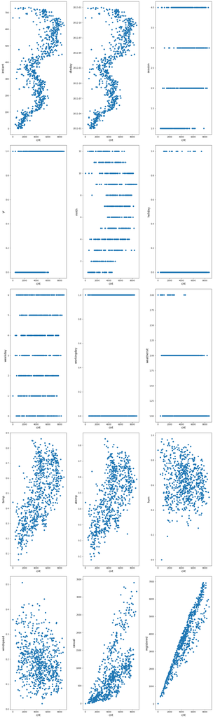

```python
plot_all(bike_data, "cnt")
```

Es schein einige Variablen zu geben, die mit der Anzahl an vermieteten Fahrrädern zusammenhängen, z.B. die Wettersituation, die Temparatur oder ob es ein Feiertag ist. Zunächst werden alle Variablen aber im Model behalten.

# Aufgabe 1

Es werden zwei verschiedene multiple Regressionsmodelle trainiert.

## Stochastic Gradient Descent

Zuerst wird eine Methode zum Trainieren eines linearen Regressionsmodells verwendet, die sich besser für Fälle eignet, in denen es eine große Anzahl von Merkmalen gibt - den Stochastic Gradient Descent

#### Laden und Aufbereiten der Daten

Die Daten werden wie zuvor wieder geladen, aufbereitet und aufgeteilt.

```python
bike_data_gd = pd.read_csv("02_Bike_rental.csv",sep=',')

bike_data_gd['casual'] = bike_data_gd['casual']/bike_data_gd['cnt']
bike_data_gd['registered'] = bike_data_gd['registered']/bike_data_gd['cnt']
```

Danach wird das Datenset wieder aufgeteilt - in einen Teil für die Feature Variablen und in einen für die zu bestimmende Variable. Das Datum wird dabei nicht verwendet, da Jahreszeit, Jahr und Monat verfügbar sind. Zudem werden Casual und Registered als Prozentuale angeben, da sie zusammen wieder cnt ergeben würden.

```python
feature_set = ['season', 'yr', 'mnth', 'holiday', 'weekday', 'workingday', 'weathersit', 'temp', 'atemp', 'hum', 'windspeed', 'casual', 'registered']

X = bike_data_gd[feature_set]
y = bike_data_gd.cnt
```

```python
# Partition data into training and testing set
X_train,X_test, y_train, y_test = train_test_split(X, y, test_size=0.2, random_state=42)
```

Danach wird das Regressionsmodell trainiert.

```python
# Import linear regression model
from sklearn.linear_model import SGDRegressor
# Create linear regression model
sgd_reg = SGDRegressor(max_iter=1000, tol=1e-5, penalty=None, eta0=0.01, n_iter_no_change=100, random_state=42)
# Fit the linear regression model
sgd_reg.fit(X_train, y_train.ravel())# y.ravel() because fit() expects 1D target
```

```
SGDRegressor(n_iter_no_change=100, penalty=None, random_state=42, tol=1e-05)
```

Zuletzt werden die Ergebnisse evaluiert.

```python
predictions_train_sgd_reg = sgd_reg.predict(X_train)

# Evaluate mean absolute error
print('Mean Absolute Error(MAE):', mean_absolute_error(y_train,predictions_train_sgd_reg))

# Evaluate mean squared error
print("Mean Squared Error(MSE):", mean_squared_error(y_train, predictions_train_sgd_reg))

# Evaluate root mean squared error
print("Root Mean Squared Error(RMSE):", np.sqrt(mean_squared_error(y_train, predictions_train_sgd_reg)))

# Evaluate R2-square
print("R2-Square:",r2_score(y_train, predictions_train_sgd_reg))
```

```
Mean Absolute Error(MAE): 611.2195853584498
Mean Squared Error(MSE): 670271.7682691939
Root Mean Squared Error(RMSE): 818.7012692485544
R2-Square: 0.8171504801250339
```

```python
# Predict the values given test set
predictions_test_sgd_reg = sgd_reg.predict(X_test)

# Evaluate mean absolute error
print('Mean Absolute Error(MAE):', mean_absolute_error(y_test,predictions_test_sgd_reg))

# Evaluate mean squared error
print("Mean Squared Error(MSE):", mean_squared_error(y_test, predictions_test_sgd_reg))

# Evaluate root mean squared error
print("Root Mean Squared Error(RMSE):", np.sqrt(mean_squared_error(y_test, predictions_test_sgd_reg)))

# Evaluate R2-square
print("R2-Square:",r2_score(y_test, predictions_test_sgd_reg))
```

```
Mean Absolute Error(MAE): 626.9140014791808
Mean Squared Error(MSE): 724856.4259365731
Root Mean Squared Error(RMSE): 851.3850045288401
R2-Square: 0.8192324926843084
```

Die Evaluationsergebnisse unterscheiden sich nur minimal. Das Testset performt besser als das Trainingsset, was auf Underfitting hinweisen könnte, d.h., dass die Variablen die Zielvariable nicht ausreichend gut beschreiben.

## Ridge Regression

Das nächste angewendete Regressionsmodell ist die Ridge Regression.

Zunächst wird der Datensatz eingelesen, das Feature Set definiert und damit die jeweiligen Teile X und Y erstellt. Dabei wird das Datum nicht mit in das Feature Set genommen, da dieses nicht nötig ist, da Season, Year und Month vorhanden sind.

```python
bike_data_rid = pd.read_csv("02_Bike_rental.csv",sep=',')

bike_data_rid['dteday'] = pd.to_datetime(bike_data_rid['dteday'])

bike_data_rid['casual'] = bike_data_rid['casual']/bike_data_rid['cnt']
bike_data_rid['registered'] = bike_data_rid['registered']/bike_data_rid['cnt']

X = bike_data_rid[feature_set]
y = bike_data_rid.cnt

X_train_rid, X_test_rid, y_train_rid, y_test_rid = train_test_split(X, y, test_size=0.3, random_state=42)


##scaler = StandardScaler()
##X_train_rid = scaler.fit_transform(X_train_rid)
##X_test_rid = scaler.transform(X_test_rid)
```

```python
#Ridge Regression Model
ridgeReg = Ridge(alpha=0.1, solver="cholesky")

ridgeReg.fit(X_train_rid,y_train_rid)

#train and test scorefor ridge regression
train_score_ridge = ridgeReg.score(X_train_rid, y_train_rid)
test_score_ridge = ridgeReg.score(X_test_rid, y_test_rid)

print("\nRidge Model............................................\n")
print("The train score for ridge model is {}".format(train_score_ridge))
print("The test score for ridge model is {}".format(test_score_ridge))
```

```
Ridge Model............................................

The train score for ridge model is 0.8150595987066035
The test score for ridge model is 0.8285730044962519
```

Als nächstes werden Predictions mit dem Trainings- und dem Testmodell erstellt und diese evaluiert.

```python
predictions_train_rid = ridgeReg.predict(X_train_rid)

# Evaluate mean absolute error
print('Mean Absolute Error(MAE):', mean_absolute_error(y_train_rid,predictions_train_rid))

# Evaluate mean squared error
print("Mean Squared Error(MSE):", mean_squared_error(y_train_rid, predictions_train_rid))

# Evaluate root mean squared error
print("Root Mean Squared Error(RMSE):", np.sqrt(mean_squared_error(y_train_rid, predictions_train_rid)))

# Evaluate R2-square
print("R2-Square:",r2_score(y_train_rid, predictions_train_rid))
```

```
Mean Absolute Error(MAE): 601.1814938194796
Mean Squared Error(MSE): 672980.2976078253
Root Mean Squared Error(RMSE): 820.3537636945571
R2-Square: 0.8150595987066035
```

```python
predictions_test_rid = ridgeReg.predict(X_test_rid)

# Evaluate mean absolute error
print('Mean Absolute Error(MAE):', mean_absolute_error(y_test_rid,predictions_test_rid))

# Evaluate mean squared error
print("Mean Squared Error(MSE):", mean_squared_error(y_test_rid, predictions_test_rid))

# Evaluate root mean squared error
print("Root Mean Squared Error(RMSE):", np.sqrt(mean_squared_error(y_test_rid, predictions_test_rid)))

# Evaluate R2-square
print("R2-Square:",r2_score(y_test_rid, predictions_test_rid))
```

```
Mean Absolute Error(MAE): 611.3430184271126
Mean Squared Error(MSE): 682102.1997673603
Root Mean Squared Error(RMSE): 825.8947873472506
R2-Square: 0.8285730044962519
```

Bei der Ridge Regression ist wieder das Ergbnis des Testdatensatzes besser als das Ergebnis des Trainingsdatensatzes, was ebenfalls auf Underfitting hinweisen könnte.

Von den beiden Methoden würde ich mich für die Ridge Regression entscheiden, da der R2 Wert des Test-Modells besser ist als bei Gradient Descent, auch wenn die Differenz zwischen Traings- und Testmodell bei dem Ridge Modell größer ist.

# Aufgabe 2 Polynominale Regression

#### 1. Model

#### Laden und Aufbereiten der Daten.

```python
bike_data_pr = pd.read_csv("02_Bike_rental.csv",sep=',')

bike_data_pr['casual'] = bike_data_pr['casual']/bike_data_pr['cnt']
bike_data_pr['registered'] = bike_data_pr['registered']/bike_data_pr['cnt']

X = bike_data_pr[feature_set]
y = bike_data_pr.cnt
```

#### Fitting Polynomial Regression to the dataset

Zunächst wird das Polynominale Modell gefittet. Zuerst mit einen Grad von 2. Danach wird die X Variable dem Polynominalen Modell angepasst.

```python
# Fitting Polynomial Regression to the dataset
from sklearn.preprocessing import PolynomialFeatures

poly = PolynomialFeatures(degree = 2, include_bias=False)
X_poly = poly.fit_transform(X)
```

```python
# Import train_test_split function from
from sklearn.model_selection import train_test_split

# Split X and y into training and testing sets
X_train, X_test, y_train, y_test = train_test_split(X_poly, y,test_size=0.2,random_state=42)
```

```python
from sklearn.linear_model import LinearRegression

lin_reg_poly = LinearRegression()
lin_reg_poly.fit(X_train, y_train)
```

```
LinearRegression()
```

Nun wird das Polynomial Regressionsmodell evaluiert.

```python
predictions_train_lin_reg_poly = lin_reg_poly.predict(X_train)

# Evaluate mean absolute error
print('Mean Absolute Error(MAE):', mean_absolute_error(y_train,predictions_train_lin_reg_poly))

# Evaluate mean squared error
print("Mean Squared Error(MSE):", mean_squared_error(y_train, predictions_train_lin_reg_poly))

# Evaluate root mean squared error
print("Root Mean Squared Error(RMSE):", np.sqrt(mean_squared_error(y_train, predictions_train_lin_reg_poly)))

# Evaluate R2-square
print("R2-Square:",r2_score(y_train, predictions_train_lin_reg_poly))
```

```
Mean Absolute Error(MAE): 392.82975056165964
Mean Squared Error(MSE): 265979.3935396037
Root Mean Squared Error(RMSE): 515.7319008356994
R2-Square: 0.9274410668810703
```

```python
# Predict the values given test set
predictions_test_lin_reg_poly = lin_reg_poly.predict(X_test)

# Evaluate mean absolute error
print('Mean Absolute Error(MAE):', mean_absolute_error(y_test,predictions_test_lin_reg_poly))

# Evaluate mean squared error
print("Mean Squared Error(MSE):", mean_squared_error(y_test, predictions_test_lin_reg_poly))

# Evaluate root mean squared error
print("Root Mean Squared Error(RMSE):", np.sqrt(mean_squared_error(y_test, predictions_test_lin_reg_poly)))

# Evaluate R2-square
print("R2-Square:",r2_score(y_test, predictions_test_lin_reg_poly))
```

```
Mean Absolute Error(MAE): 538.4817680642597
Mean Squared Error(MSE): 624496.9289475349
Root Mean Squared Error(RMSE): 790.2511809213162
R2-Square: 0.8442605333514301
```

Es ist zu sehen, dass alle Werte für das Modell im Trainingdatensatz besser sind als im Testdatensatz. Dies deutet auf Overfitting hin. Ein hoher R²-Wert auf den Trainingsdaten bedeutet, dass das Modell die Trainingsdaten gut erklären kann, aber ein niedrigerer R²-Wert auf den Testdaten bedeutet, dass es Schwierigkeiten hat, neue, unbekannte Daten zu erklären.

#### 2. Model

```python
poly_2 = PolynomialFeatures(degree = 3, include_bias=False)
X_poly_2 = poly_2.fit_transform(X)
```

```python
# Split X and y into training and testing sets
X_train_2, X_test_2, y_train_2, y_test_2 = train_test_split(X_poly, y,test_size=0.2,random_state=42)
```

```python
lin_reg_poly_2 = LinearRegression()
lin_reg_poly_2.fit(X_train_2, y_train_2)
```

```
LinearRegression()
```

```python
predictions_train_lin_reg_poly_2 = lin_reg_poly.predict(X_train_2)
# Import the required libraries
import numpy as np
from sklearn.metrics import mean_absolute_error
from sklearn.metrics import mean_squared_error
from sklearn.metrics import r2_score

# Evaluate mean absolute error
print('Mean Absolute Error(MAE):', mean_absolute_error(y_train_2,predictions_train_lin_reg_poly_2))

# Evaluate mean squared error
print("Mean Squared Error(MSE):", mean_squared_error(y_train_2, predictions_train_lin_reg_poly_2))

# Evaluate root mean squared error
print("Root Mean Squared Error(RMSE):", np.sqrt(mean_squared_error(y_train_2, predictions_train_lin_reg_poly_2)))

# Evaluate R2-square
print("R2-Square:",r2_score(y_train_2, predictions_train_lin_reg_poly_2))
```

```
Mean Absolute Error(MAE): 392.82975056165964
Mean Squared Error(MSE): 265979.3935396037
Root Mean Squared Error(RMSE): 515.7319008356994
R2-Square: 0.9274410668810703
```

```python
# Predict the values given test set
predictions_test_lin_reg_poly_2 = lin_reg_poly.predict(X_test_2)
import numpy as np
from sklearn.metrics import mean_absolute_error
from sklearn.metrics import mean_squared_error
from sklearn.metrics import r2_score

# Evaluate mean absolute error
print('Mean Absolute Error(MAE):', mean_absolute_error(y_test_2,predictions_test_lin_reg_poly_2))

# Evaluate mean squared error
print("Mean Squared Error(MSE):", mean_squared_error(y_test_2, predictions_test_lin_reg_poly_2))

# Evaluate root mean squared error
print("Root Mean Squared Error(RMSE):", np.sqrt(mean_squared_error(y_test_2, predictions_test_lin_reg_poly_2)))

# Evaluate R2-square
print("R2-Square:",r2_score(y_test_2, predictions_test_lin_reg_poly_2))
```

```
Mean Absolute Error(MAE): 538.4817680642597
Mean Squared Error(MSE): 624496.9289475349
Root Mean Squared Error(RMSE): 790.2511809213162
R2-Square: 0.8442605333514301
```

Generell würde ich mich für das Ridge Regressions Modell entscheiden, da hier der Unterschied zwischen den Ergebnissen des Trainings - und Testdatensatzes geringer ist.

# Aufgabe 3

## Hyperparameter Tuning

Als nächstes wird Hyperparameter Tuning auf die Ridge Regression angewendet um die optimalen Parameter zu bestimmen. Zunächst werden mit der Funktion get_params() alles möglichen Parameter angezeigt die zum Tuning verwendet werden könnten.

```python
ridgeReg.get_params()
```

```
{'alpha': 0.1,
 'copy_X': True,
 'fit_intercept': True,
 'max_iter': None,
 'normalize': 'deprecated',
 'positive': False,
 'random_state': None,
 'solver': 'cholesky',
 'tol': 0.001}
```

Danach werden die Werte festgelegt, die beim Hyperparameter Tuning durchsucht werden sollen.

```python
from scipy.stats import loguniform

space = {
'solver' : ['svd', 'cholesky', 'lsqr', 'sag', 'auto'],
'alpha' : [1e-5, 1e-4, 1e-3, 1e-2, 1e-1,0.1, 1, 10, 100]
}
```

Nun wird das Tuning durchgeführt, indem das Modell mit verschiedenen Hyperparameter-Kombinationen trainiert und bewertet wird.

```python
from sklearn.model_selection import RepeatedKFold
from sklearn.model_selection import GridSearchCV

# define model
model = Ridge(random_state=42)
# define search
search = GridSearchCV(model, space, scoring='r2', n_jobs=-1, cv=10)
# execute search
result = search.fit(X_train_rid, y_train_rid)
# summarize result
print('Best Score: %s' % result.best_score_)
print('Best Hyperparameters: %s' % result.best_params_)
```

```
Best Score: 0.789805745927693
Best Hyperparameters: {'alpha': 0.1, 'solver': 'sag'}
```

```python
#Trainieren des Models mit den neuen Parametern
ridgeReg_new = Ridge(alpha=1, fit_intercept= True, solver= 'sag')
ridgeReg_new.fit(X_train_rid, y_train_rid)

#train and test scorefor ridge regression
train_score_ridge_new = ridgeReg_new.score(X_train_rid, y_train_rid)
test_score_ridge_new = ridgeReg_new.score(X_test_rid, y_test_rid)

print("\nRidge Model............................................\n")
print("The train score for ridge model is {}".format(train_score_ridge_new))
print("The test score for ridge model is {}".format(test_score_ridge_new))
print("The grid search for ridge model is {}".format(result.best_score_))
```

```
Ridge Model............................................

The train score for ridge model is 0.8134456271992574
The test score for ridge model is 0.8279272381935532
The grid search for ridge model is 0.789805745927693
```

```python
predictions_train_rid_new = ridgeReg_new.predict(X_train_rid)

# Evaluate mean absolute error
print('Mean Absolute Error(MAE):', mean_absolute_error(y_train_rid,predictions_train_rid_new))

# Evaluate mean squared error
print("Mean Squared Error(MSE):", mean_squared_error(y_train_rid, predictions_train_rid_new))

# Evaluate root mean squared error
print("Root Mean Squared Error(RMSE):", np.sqrt(mean_squared_error(y_train_rid, predictions_train_rid_new)))

# Evaluate R2-square
print("R2-Square:",r2_score(y_train_rid, predictions_train_rid_new))
```

```
Mean Absolute Error(MAE): 606.1605074503785
Mean Squared Error(MSE): 678853.3843846902
Root Mean Squared Error(RMSE): 823.925593961427
R2-Square: 0.8134456271992574
```

```python
predictions_test_rid_new = ridgeReg_new.predict(X_test_rid)

# Evaluate mean absolute error
print('Mean Absolute Error(MAE):', mean_absolute_error(y_test_rid,predictions_test_rid_new))

# Evaluate mean squared error
print("Mean Squared Error(MSE):", mean_squared_error(y_test_rid, predictions_test_rid_new))

# Evaluate root mean squared error
print("Root Mean Squared Error(RMSE):", np.sqrt(mean_squared_error(y_test_rid, predictions_test_rid_new)))

# Evaluate R2-square
print("R2-Square:",r2_score(y_test_rid, predictions_test_rid_new))
```

```
Mean Absolute Error(MAE): 614.3426041120141
Mean Squared Error(MSE): 684671.6819793778
Root Mean Squared Error(RMSE): 827.4488999203381
R2-Square: 0.8279272381935532
```

Es ist zu sehen, dass durch das Hyperparameter Tuning der gefundene best score nieriger ist als der vorherige. Dies kann wiederum ein Zeichen für Overfitting sein.

### Cross_Validation

Als nächstes Überprüfen wir mithilfe von Cross Validation wie sehr die zufällige Aufteilung von Test- und Traingsmodell das Ergebnis beeinflussen kann.

```python
scores = cross_val_score(ridgeReg_new, X_train_rid,y_train_rid, scoring='r2')
print("Cross-validation scores: {}".format(scores))
print("Average cross-validation score: {:.2f}".format(scores.mean()))
print("Standard deviation: {:.2f}".format(scores.std()))
```

```
Cross-validation scores: [0.78767339 0.85626931 0.79035238 0.65753909 0.87078607]
Average cross-validation score: 0.79
Standard deviation: 0.08
```

Es ist zu sehen, dass die Cross-Validation Werte sehr weit auseinander gehen, von dem höchsten Wert mit 0.87 bis zum niedrigsten mit 0.65 - das kann darauf hindeuten, dass das Ergebnis des Regressionsmodell stark abhängig davon ist, wie das Trainings- und Testdatenset aufgeteilt werden.

```python
#r2 scores
y_pred_train_rid = ridgeReg_new.predict(X_train_rid)
y_pred_test_rid = ridgeReg_new.predict(X_test_rid)

print("R2 of training data:",r2_score(y_train_rid, y_pred_train_rid))
print("R2 of test data:",r2_score(y_test_rid, y_pred_test_rid))
print("R2 of cross-validation:", cross_val_score(ridgeReg, X_train_rid,y_train_rid,scoring='r2').mean())
```

```
R2 of training data: 0.8134456271992574
R2 of test data: 0.8279272381935532
R2 of cross-validation: 0.7931034305572634
```

Das Ergebnis der Cross-Validation ist schlecheter als das des Trainingssets, dies kann auf eine hohe Varianz (Overfitting) hinweisen, also dass es zuviel erklärende Variablen enthält.

# Aufgabe 4

### Ensemble Learning

Als nächstes wird eine Ensemble Learning Technik auf das Datenset angewandt, um zu sehen, ob bessere Ergbnisse als zuvor erzielt werden können. Dafür wird der RandomForestRegressor benutzt - dieser eignet sich auch gut für Regressions Modelle. Zunächst wird wieder ein Trainings- und Testdatenset erstellt, welches danach für das Model verwendet wird.

```python
bike_data_rf = pd.read_csv("02_Bike_rental.csv",sep=',')

bike_data_rf['dteday'] = pd.to_datetime(bike_data_rf['dteday'])

feature_set = ['season', 'yr', 'mnth', 'holiday', 'weekday', 'workingday', 'weathersit', 'temp', 'atemp', 'hum', 'windspeed']

X = bike_data_rf[feature_set]
y = bike_data_rf.cnt

X_train_rf, X_test_rf, y_train_rf, y_test_rf = train_test_split(X, y, test_size=0.3, random_state=42)
```

```python
from sklearn.ensemble import RandomForestRegressor


rf = RandomForestRegressor(n_estimators=25,
            random_state=42)

rf.fit(X_train_rf, y_train_rf)
```

```
RandomForestRegressor(n_estimators=25, random_state=42)
```

```python
y_pred_rf = rf.predict(X_test_rf)
print(r2_score(y_test_rf, y_pred_rf))
```

```
0.8912132057381534
```

Der R2 Score ist mit dem RandomForestRegressor besser als zuvor. Um die Ergebnisse nochmals zu untersuchen, wird als nächstes erneut die Cross-Validation angewandt.

### Cross-Validation Random Forest Regressor

```python
scores_rf = cross_val_score(rf, X_train_rf,y_train_rf, scoring='r2')
print("Cross-validation scores: {}".format(scores_rf))
print("Average cross-validation score: {:.2f}".format(scores_rf.mean()))
print("Standard deviation: {:.2f}".format(scores_rf.std()))
```

```
Cross-validation scores: [0.82806062 0.84704166 0.83480813 0.79924482 0.86066427]
Average cross-validation score: 0.83
Standard deviation: 0.02
```

```python
#r2 scores
y_pred_train_rf = rf.predict(X_train_rf)
y_pred_test_rf = rf.predict(X_test_rf)

print("R2 of training data:",r2_score(y_train_rf, y_pred_train_rf))
print("R2 of test data:",r2_score(y_test_rf, y_pred_test_rf))
print("R2 of cross-validation:", cross_val_score(rf, X_train_rf,y_train_rf,scoring='r2').mean())
```

```
R2 of training data: 0.9778661177680406
R2 of test data: 0.8912132057381534
R2 of cross-validation: 0.8339639005624662
```

### Feature Importance

Da zuvor immer eine hohe Varianz sichtbar war, wird zum Ende nocheinmal die Feature Importance untersucht, um festzustellen, welche Variablen entscheidend für das Regressionsmodell waren. Dafür wird für jedes Feature deren Feature_importance Wert ausgegeben und am Ende nochmals grafisch dargestellt.

```python
for name, score in zip(feature_set, rf.feature_importances_):
    print(name, score)
```

```
season 0.0515704041929676
yr 0.26883317980051774
mnth 0.02441354183531263
holiday 0.002065828029033914
weekday 0.016502540522795445
workingday 0.004691422665289431
weathersit 0.012642081195783673
temp 0.3247899133541311
atemp 0.20530213568726757
hum 0.058737220728730354
windspeed 0.030451731988170624
```

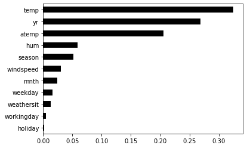

```python
#Create a pd.Series of features importances
importances_rf = pd.Series(rf.feature_importances_, index = feature_set)
# Sort importances_rnd_clf
sorted_importances_rf = importances_rf.sort_values()
# Make a horizontal bar plot
sorted_importances_rf.plot(kind='barh', color='black'); plt.show()
```

Es zeigt sich, das vor allem temp, yr und atemp wichtig für das Modell sind. Ich würde mich am Ende für den RandomForestRegressor entscheiden, da dieser die besten Werte bisher hatte. Sowohl im normal als auch in der Cross-Validation. Es könnte noch probiert werden das Modell mit weniger Variablen zu trainiern und damit noch bessere Werte zu erhalten.